# Loan Default Prediction

## 1. Context

A major proportion of retail bank profit comes from interest in the form of home loans. These loans are borrowed by regular income/high-earning customers. Banks are most fearful of defaulters, as bad loans (NPA) usually eat up a major chunk of their profits. Therefore, it is important for banks to be judicious while approving loans for their customer base.

The approval process for the loans is multifaceted. Through this process, the bank tries to check the creditworthiness of the applicant on the basis of a manual study of various aspects of the application. The entire process is not only effort-intensive but also prone to wrong judgment/approval owing to human error and bias .

## 2. Objective

Build a classification model to predict clients who are likely to default on their loan and give recommendations to the bank on the important features to consider while approving a loan.

## 3. Data Description

The Home Equity dataset (HMEQ) contains baseline and loan performance information for recent home equity loans. The target (BAD) is a binary variable that indicates whether an applicant has ultimately defaulted or has been severely delinquent. There are 12 input variables registered for each applicant.

**Data Dictionary**

- BAD: 1 = Client defaulted on loan, 0 = loan repaid
- LOAN: Amount of loan approve.
- \MORTDUE: Amount due on the existing mortgage
- VALUE: Current value of the property
- REASON: Reason for the loan request (HomeImp = home improvement, DebtCon= debt consolidation which means taking out a new loan to pay off other liabilities and consumer debts)
- JOB: The type of job that loan applicant has such as manager, self, etc.
- YOJ: Years at present job
- DEROG: Number of major derogatory reports (which indicate serious delinquency or late payments).
- DELINQ: Number of delinquent credit lines (a line of credit becomes delinquent when a borrower does not make the minimum required payments 30 to 60 days past the day on which the payments were due)
- CLAGE: Age of the oldest credit line in months
- NINQ: Number of recent credit inquiries
- CLNO: Number of existing credit lines
- DEBTINC: Debt-to-income ratio (all monthly debt payments divided by gross monthly income. This number is one of the ways lenders measure a borrower’s ability to manage the monthly payments to repay the money they plan to borrow).

## 4. Importing necessary libraries and data

```python
import pandas as pd
import numpy as np
import matplotlib.pyplot as plt
import seaborn as sns

import warnings
warnings.filterwarnings("ignore")

# Removes the limit for the number of displayed columns
pd.set_option("display.max_columns", None)

# Sets the limit for the number of displayed rows
pd.set_option("display.max_rows", 200)

# To build models for prediction
from sklearn.model_selection import train_test_split, cross_val_score, KFold
from sklearn.linear_model import LinearRegression, Ridge, Lasso, ElasticNet
from sklearn.tree import DecisionTreeRegressor
from sklearn.ensemble import RandomForestRegressor,BaggingRegressor

# Algorithms to use
from sklearn.linear_model import LogisticRegression
from sklearn.svm import SVC
from sklearn.tree import DecisionTreeClassifier
from sklearn.ensemble import BaggingClassifier
from sklearn.ensemble import RandomForestClassifier

# Metrics to evaluate the model performance
from sklearn import metrics
from sklearn.metrics import f1_score, accuracy_score, recall_score, precision_score, confusion_matrix, classification_report, precision_recall_curve
from sklearn import tree
from sklearn.metrics import make_scorer,mean_squared_error, r2_score, mean_absolute_error

# To encode categorical variables
from sklearn.preprocessing import LabelEncoder
from sklearn.preprocessing import StandardScaler, MinMaxScaler, OneHotEncoder

# For tuning the model
from sklearn.model_selection import GridSearchCV
```

## 5. Data Overview

- Observations
- Sanity checks

```python
# Read the loan default dataset file
data = pd.read_csv("Dataset - Loan Default.csv")
```

```python
# Copying data to another variable to avoid any changes to original data
same_data = data.copy()
```

```python
# View the first 5 rows of the dataset
data.head()
```

|  | BAD | LOAN | MORTDUE | VALUE | REASON | JOB | YOJ | DEROG | DELINQ | CLAGE | NINQ | CLNO | DEBTINC |
| --- | --- | --- | --- | --- | --- | --- | --- | --- | --- | --- | --- | --- | --- |
| 0 | 1 | 1100 | 25860.0 | 39025.0 | HomeImp | Other | 10.5 | 0.0 | 0.0 | 94.366667 | 1.0 | 9.0 | NaN |
| 1 | 1 | 1300 | 70053.0 | 68400.0 | HomeImp | Other | 7.0 | 0.0 | 2.0 | 121.833333 | 0.0 | 14.0 | NaN |
| 2 | 1 | 1500 | 13500.0 | 16700.0 | HomeImp | Other | 4.0 | 0.0 | 0.0 | 149.466667 | 1.0 | 10.0 | NaN |
| 3 | 1 | 1500 | NaN | NaN | NaN | NaN | NaN | NaN | NaN | NaN | NaN | NaN | NaN |
| 4 | 0 | 1700 | 97800.0 | 112000.0 | HomeImp | Office | 3.0 | 0.0 | 0.0 | 93.333333 | 0.0 | 14.0 | NaN |

```python
data.shape
```

```
(5960, 13)
```

```python
# Checking the info of the data
data.info()
```

```
<class 'pandas.core.frame.DataFrame'>
RangeIndex: 5960 entries, 0 to 5959
Data columns (total 13 columns):
 #   Column   Non-Null Count  Dtype
---  ------   --------------  -----
 0   BAD      5960 non-null   int64
 1   LOAN     5960 non-null   int64
 2   MORTDUE  5442 non-null   float64
 3   VALUE    5848 non-null   float64
 4   REASON   5708 non-null   object
 5   JOB      5681 non-null   object
 6   YOJ      5445 non-null   float64
 7   DEROG    5252 non-null   float64
 8   DELINQ   5380 non-null   float64
 9   CLAGE    5652 non-null   float64
 10  NINQ     5450 non-null   float64
 11  CLNO     5738 non-null   float64
 12  DEBTINC  4693 non-null   float64
dtypes: float64(9), int64(2), object(2)
memory usage: 605.4+ KB
```

**Observations:**

- REASON & JOB variables are **object data type**, the rest of the colummns are **numeric data type**.
- Some columns have non-null values, compared to the total number of entries in the data. So we will need to see if we can treat null-values.

```python
# Let's check for duplicate values in the data
data.duplicated().sum()
```

```
0
```

```python
# Let's check for missing values in the data
round(data.isnull().sum() / data.isnull().count() * 100, 2)
```

```
BAD         0.00
LOAN        0.00
MORTDUE     8.69
VALUE       1.88
REASON      4.23
JOB         4.68
YOJ         8.64
DEROG      11.88
DELINQ      9.73
CLAGE       5.17
NINQ        8.56
CLNO        3.72
DEBTINC    21.26
dtype: float64
```

**Observations**

DEBTINC and DEROG have higher missing values and we need to consider how to improve these empty values.

```python
# To view how many defaulted vs those that did repay the loan
data['BAD'].value_counts()
```

```
BAD
0    4771
1    1189
Name: count, dtype: int64
```

```python
data['DEROG'].value_counts()
```

```
DEROG
0.0     4527
1.0      435
2.0      160
3.0       58
4.0       23
5.0       15
6.0       15
7.0        8
8.0        6
9.0        3
10.0       2
Name: count, dtype: int64
```

```python
data['DELINQ'].value_counts()
```

```
DELINQ
0.0     4179
1.0      654
2.0      250
3.0      129
4.0       78
5.0       38
6.0       27
7.0       13
8.0        5
10.0       2
11.0       2
15.0       1
12.0       1
13.0       1
Name: count, dtype: int64
```

## 5. Exploratory Data Analysis (EDA)

- EDA is an important part of any project involving data.
- It is important to investigate and understand the data better before building a model with it.

**Observations**

1. Different variables might indicate a higher possibility to predict a default happening. These could be: JOB, YOJ, DEROG, DELINQ, DEBTINC.
2. The bank could derive other interesting insights among its variables like, higher risk of default on properties with high value.

```python
#  Statistical summary of the data
data.describe().T
```

|  | count | mean | std | min | 25% | 50% | 75% | max |
| --- | --- | --- | --- | --- | --- | --- | --- | --- |
| BAD | 5960.0 | 0.199497 | 0.399656 | 0.000000 | 0.000000 | 0.000000 | 0.000000 | 1.000000 |
| LOAN | 5960.0 | 18607.969799 | 11207.480417 | 1100.000000 | 11100.000000 | 16300.000000 | 23300.000000 | 89900.000000 |
| MORTDUE | 5442.0 | 73760.817200 | 44457.609458 | 2063.000000 | 46276.000000 | 65019.000000 | 91488.000000 | 399550.000000 |
| VALUE | 5848.0 | 101776.048741 | 57385.775334 | 8000.000000 | 66075.500000 | 89235.500000 | 119824.250000 | 855909.000000 |
| YOJ | 5445.0 | 8.922268 | 7.573982 | 0.000000 | 3.000000 | 7.000000 | 13.000000 | 41.000000 |
| DEROG | 5252.0 | 0.254570 | 0.846047 | 0.000000 | 0.000000 | 0.000000 | 0.000000 | 10.000000 |
| DELINQ | 5380.0 | 0.449442 | 1.127266 | 0.000000 | 0.000000 | 0.000000 | 0.000000 | 15.000000 |
| CLAGE | 5652.0 | 179.766275 | 85.810092 | 0.000000 | 115.116702 | 173.466667 | 231.562278 | 1168.233561 |
| NINQ | 5450.0 | 1.186055 | 1.728675 | 0.000000 | 0.000000 | 1.000000 | 2.000000 | 17.000000 |
| CLNO | 5738.0 | 21.296096 | 10.138933 | 0.000000 | 15.000000 | 20.000000 | 26.000000 | 71.000000 |
| DEBTINC | 4693.0 | 33.779915 | 8.601746 | 0.524499 | 29.140031 | 34.818262 | 39.003141 | 203.312149 |

```python
# List of all important categorical variables
cat_col = ['REASON', 'JOB']

# Printing the number of occurrences of each unique value in each categorical column in %
for column in cat_col:
    print(data[column].value_counts(1)*100)
    print("-" * 50)
```

```
REASON
DebtCon    68.815697
HomeImp    31.184303
Name: proportion, dtype: float64
--------------------------------------------------
JOB
Other      42.034853
ProfExe    22.460834
Office     16.687203
Mgr        13.501144
Self        3.397289
Sales       1.918676
Name: proportion, dtype: float64
--------------------------------------------------
```

```python
#Creating dataframes, differentiating between leads/non-leads
defaults = data[data.BAD == 1]
non_defaults = data[data.BAD == 0]

defaults.head()
```

|  | BAD | LOAN | MORTDUE | VALUE | REASON | JOB | YOJ | DEROG | DELINQ | CLAGE | NINQ | CLNO | DEBTINC |
| --- | --- | --- | --- | --- | --- | --- | --- | --- | --- | --- | --- | --- | --- |
| 0 | 1 | 1100 | 25860.0 | 39025.0 | HomeImp | Other | 10.5 | 0.0 | 0.0 | 94.366667 | 1.0 | 9.0 | NaN |
| 1 | 1 | 1300 | 70053.0 | 68400.0 | HomeImp | Other | 7.0 | 0.0 | 2.0 | 121.833333 | 0.0 | 14.0 | NaN |
| 2 | 1 | 1500 | 13500.0 | 16700.0 | HomeImp | Other | 4.0 | 0.0 | 0.0 | 149.466667 | 1.0 | 10.0 | NaN |
| 3 | 1 | 1500 | NaN | NaN | NaN | NaN | NaN | NaN | NaN | NaN | NaN | NaN | NaN |
| 5 | 1 | 1700 | 30548.0 | 40320.0 | HomeImp | Other | 9.0 | 0.0 | 0.0 | 101.466002 | 1.0 | 8.0 | 37.113614 |

```python
#  Statistical summary of the data
defaults.describe().T
```

|  | count | mean | std | min | 25% | 50% | 75% | max |
| --- | --- | --- | --- | --- | --- | --- | --- | --- |
| BAD | 1189.0 | 1.000000 | 0.000000 | 1.000000 | 1.000000 | 1.000000 | 1.000000 | 1.000000 |
| LOAN | 1189.0 | 16922.119428 | 11418.455152 | 1100.000000 | 9200.000000 | 14900.000000 | 21700.000000 | 77400.000000 |
| MORTDUE | 1083.0 | 69460.452973 | 47588.194467 | 2063.000000 | 39946.500000 | 60279.000000 | 85864.500000 | 399550.000000 |
| VALUE | 1084.0 | 98172.846227 | 74339.822506 | 8800.000000 | 59368.250000 | 82000.000000 | 116000.000000 | 855909.000000 |
| YOJ | 1124.0 | 8.027802 | 7.100735 | 0.000000 | 2.000000 | 6.000000 | 12.000000 | 41.000000 |
| DEROG | 1102.0 | 0.707804 | 1.468381 | 0.000000 | 0.000000 | 0.000000 | 1.000000 | 10.000000 |
| DELINQ | 1117.0 | 1.229185 | 1.902961 | 0.000000 | 0.000000 | 0.000000 | 2.000000 | 15.000000 |
| CLAGE | 1111.0 | 150.190183 | 84.952286 | 0.000000 | 96.033333 | 132.866667 | 193.283333 | 1168.233561 |
| NINQ | 1114.0 | 1.782765 | 2.246976 | 0.000000 | 0.000000 | 1.000000 | 3.000000 | 17.000000 |
| CLNO | 1136.0 | 21.211268 | 11.812981 | 0.000000 | 13.000000 | 20.000000 | 28.000000 | 71.000000 |
| DEBTINC | 403.0 | 39.387645 | 17.723586 | 0.524499 | 32.383046 | 38.079762 | 43.285990 | 203.312149 |

## 5.1. Univariate Analysis

```python
# Making a list of all categorical variables
num_cols = list(data.select_dtypes('number').columns)
print(num_cols)
```

```
['BAD', 'LOAN', 'MORTDUE', 'VALUE', 'YOJ', 'DEROG', 'DELINQ', 'CLAGE', 'NINQ', 'CLNO', 'DEBTINC']
```

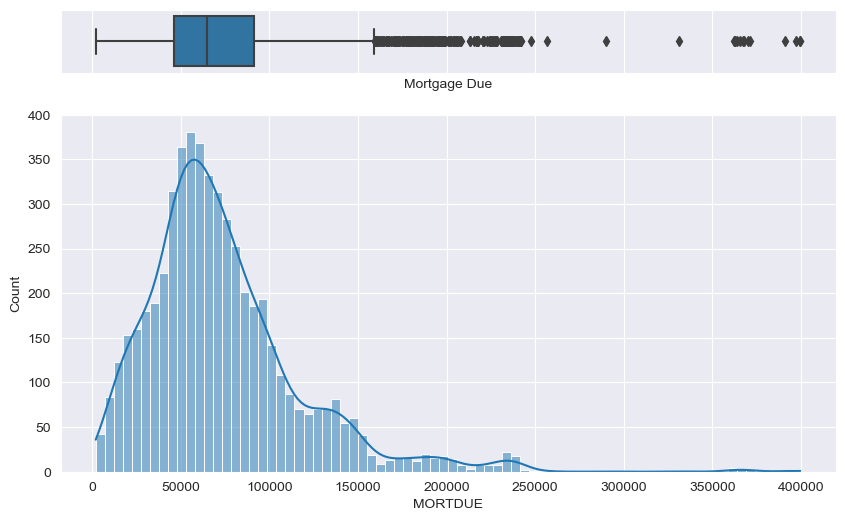

```python
f, (ax_box, ax_hist) = plt.subplots(2, sharex=True, gridspec_kw={'height_ratios': (.15, .85)}, figsize=(10, 6))
sns.set_style("darkgrid")

# Add a graph in each part
sns.boxplot(data=data, x='MORTDUE', ax=ax_box)
sns.histplot(data=data, x='MORTDUE', kde=True, ax=ax_hist)
ax_box.set(xlabel="Mortgage Due")

plt.show()
```

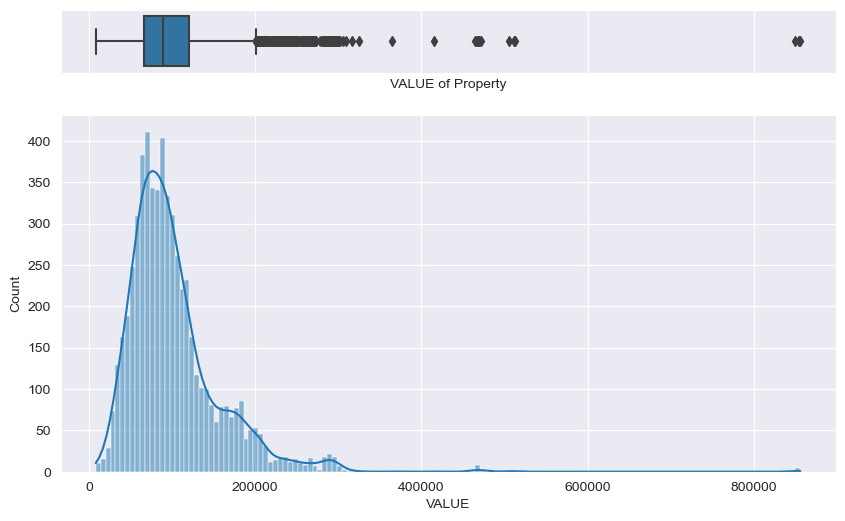

```python
f, (ax_box, ax_hist) = plt.subplots(2, sharex=True, gridspec_kw={'height_ratios': (.15, .85)}, figsize=(10, 6))
sns.set_style("darkgrid")

# Add a graph in each part
sns.boxplot(data=data, x='VALUE', ax=ax_box)
sns.histplot(data=data, x='VALUE', kde=True, ax=ax_hist)
ax_box.set(xlabel="VALUE of Property")

plt.show()
```

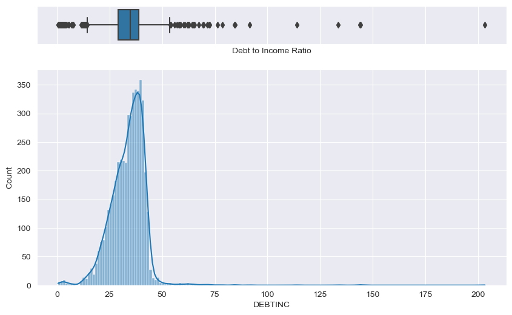

```python
f, (ax_box, ax_hist) = plt.subplots(2, sharex=True, gridspec_kw={'height_ratios': (.15, .85)}, figsize=(10, 6))
sns.set_style("darkgrid")

# Add a graph in each part
sns.boxplot(data=data, x='DEBTINC', ax=ax_box)
sns.histplot(data=data, x='DEBTINC', kde=True, ax=ax_hist)
ax_box.set(xlabel="Debt to Income Ratio")

plt.show()
```

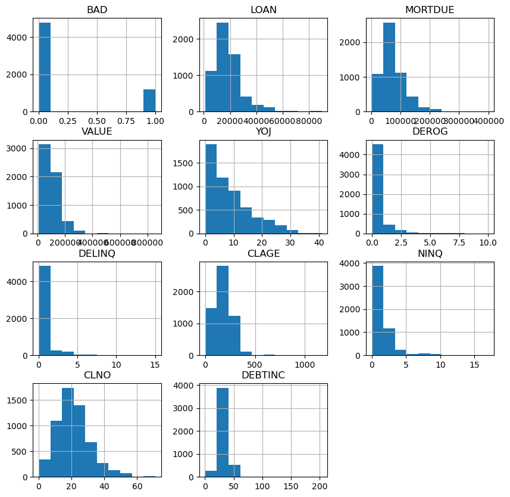

```python
# Creating histograms
data[num_cols].hist(figsize=(10,10))
plt.show()
```

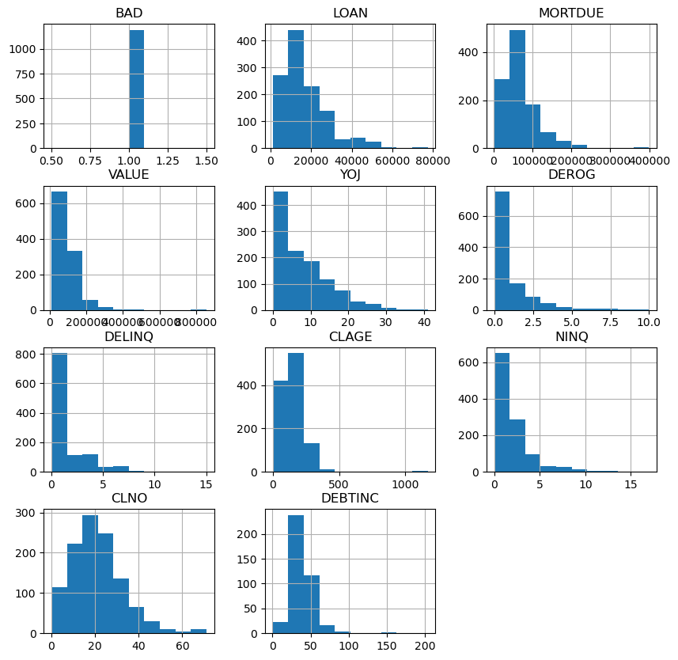

```python
# Creating histogram for defaults only
defaults[num_cols].hist(figsize=(10,10))
plt.show()
```

```python
# function to create labeled barplots

def labeled_barplot(data, feature, perc=False, n=None):
    """
    Barplot with percentage at the top

    data: dataframe
    feature: dataframe column
    perc: whether to display percentages instead of count (default is False)
    n: displays the top n category levels (default is None, i.e., display all levels)
    """

    total = len(data[feature])  # length of the column
    count = data[feature].nunique()
    if n is None:
        plt.figure(figsize=(count + 1, 5))
    else:
        plt.figure(figsize=(n + 1, 5))

    plt.xticks(rotation=90, fontsize=15)
    ax = sns.countplot(
        data=data,
        x=feature,
        palette="Paired",
        order=data[feature].value_counts().index[:n].sort_values(),
    )

    for p in ax.patches:
        if perc == True:
            label = "{:.1f}%".format(
                100 * p.get_height() / total
            )  # percentage of each class of the category
        else:
            label = p.get_height()  # count of each level of the category

        x = p.get_x() + p.get_width() / 2  # width of the plot
        y = p.get_height()  # height of the plot

        ax.annotate(
            label,
            (x, y),
            ha="center",
            va="center",
            size=12,
            xytext=(0, 5),
            textcoords="offset points",
        )  # annotate the percentage

    plt.show()  # show the plot
```

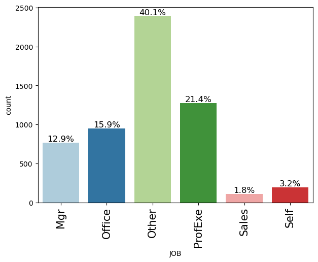

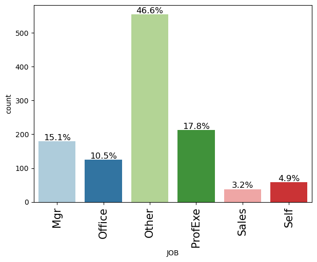

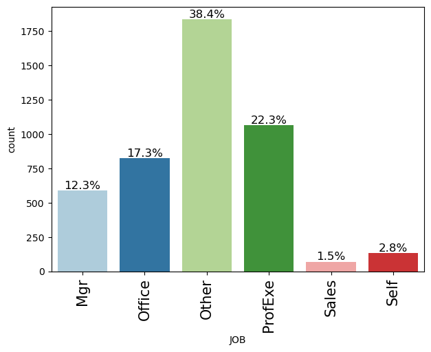

```python
labeled_barplot(data, "JOB", perc=True)
labeled_barplot(defaults, "JOB", perc=True)
labeled_barplot(non_defaults, "JOB", perc=True)
```

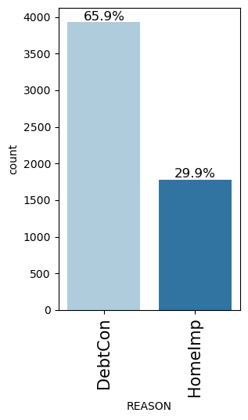

```python
labeled_barplot(data, "REASON", perc=True)
```

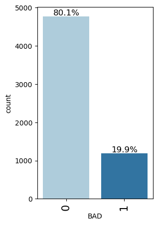

```python
labeled_barplot(data, "BAD", perc=True)
```

Almost 20% of the clients default.

## Multivariate Analysis

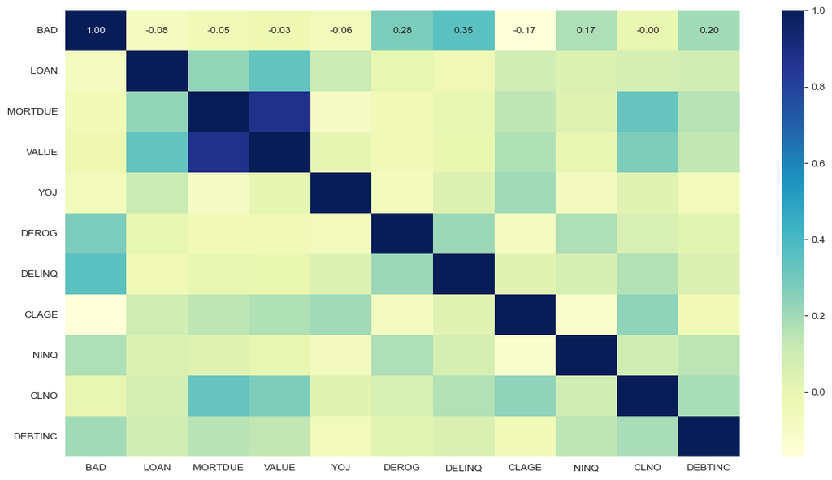

```python
# Plotting the correlation between numerical variables
plt.figure(figsize=(15,8))
sns.heatmap(data[num_cols].corr(),annot=True, fmt='0.2f', cmap='YlGnBu')
```

The graph suggests that the variables most impacting the default variable with a positive correlation: DELINQ and DEROG in that order. Followed by DEBTINC and NINQ.

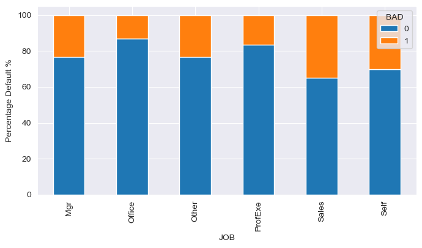

```python
(pd.crosstab(data['JOB'],data['BAD'],normalize='index')*100).plot(kind='bar',figsize=(8,4),stacked=True)
plt.ylabel('Percentage Default %')
```

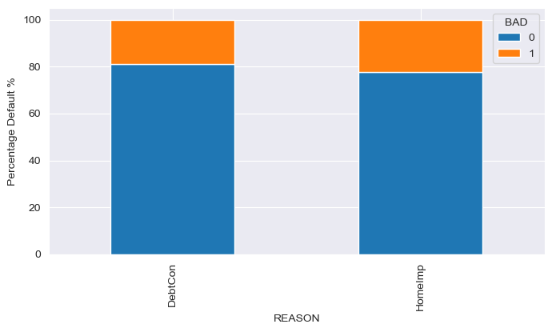

```python
(pd.crosstab(data['REASON'],data['BAD'],normalize='index')*100).plot(kind='bar',figsize=(8,4),stacked=True)
plt.ylabel('Percentage Default %')
```

## Data Preprocessing

- Missing value treatment (if needed)
- Feature engineering (if needed)
- Outlier detection and treatment (if needed)
- Preparing data for modeling
- Any other preprocessing steps (if needed)

## EDA

- It is a good idea to explore the data once again after manipulating it.

## Actionable Insights and Recommendations